# Assignment 7: ARIMA

Univeristy of Washington - Data Science Certification - Method for Data Analysis

Josh Jensen

August 16, 2016

### Assignment

Perform time series analysis on the data for **Ice Cream Production**, in the CADairyProduction.csv file to answer the following questions:

- Is this time series stationary?
- Is there a significant seasonal component?
- For the remainder from the decomposition of the time series what is the order of the ARMA(p,q) process that best fits.
- Forecast production for 12 months and examine numeric values andplot the confidence intervals. Are the confidence intervals reasonably small compared to the forecast means.

### Conclusions

We visually conclude that the ice cream production time series is stationary. Further, leveraging the Augmented Dickey-Fuller test for stationarity, we reject the null hypothesis of the series being not stationary under 95% confidence. As well, we also find that there is a significant seasonal component present in the ice cream production time series.

Moreover, we fit an ARMA(0,4) process to the remainder of the decomposed series. Finally, using an ARIMA(3,0,1)(1,1,2) process, we forecast the next 12 months of production.

### Set up

First lets load libraries and data.

```r
library(dplyr)
library(readr)
library(ggplot2)
library(forecast)
library(tseries)

# read in data
dairy <- read_csv('CADairyProduction.csv')
```

Lets inspect time range ensure the data is complet with 12 months per year.

```r
dairy %>% group_by(Year) %>% summarise(n()) %>% arrange(Year)
```

```
## Source: local data frame [19 x 2]
##
##     Year   n()
##    (int) (int)
## 1   1995    12
## 2   1996    12
## 3   1997    12
## 4   1998    12
## 5   1999    12
## 6   2000    12
## 7   2001    12
## 8   2002    12
## 9   2003    12
## 10  2004    12
## 11  2005    12
## 12  2006    12
## 13  2007    12
## 14  2008    12
## 15  2009    12
## 16  2010    12
## 17  2011    12
## 18  2012    12
## 19  2013    12
```

Now create time series object, `icecream`.

```r
icecream <- ts(dairy$Icecream.Prod, start = 1995, deltat = 1/12)
icecream
```

```
##         Jan    Feb    Mar    Apr    May    Jun    Jul    Aug    Sep    Oct
## 1995 51.595 56.086 68.453 65.722 73.730 77.994 81.475 74.981 61.530 60.022
## 1996 53.116 57.463 68.929 69.673 77.387 86.814 83.006 79.260 69.216 64.556
## 1997 55.565 58.962 72.866 74.965 75.425 85.133 83.144 75.258 70.230 61.385
## 1998 51.239 61.373 73.202 72.327 74.358 86.093 85.398 80.306 70.906 59.909
## 1999 54.842 62.058 76.594 75.760 77.564 86.014 82.940 82.679 66.571 59.571
## 2000 58.263 60.900 74.140 72.652 76.877 85.091 82.104 82.661 65.038 62.875
## 2001 56.419 62.337 68.258 74.011 79.862 85.562 86.931 77.490 67.962 62.395
## 2002 60.822 64.592 73.945 77.569 81.294 86.244 86.596 77.673 68.668 67.552
## 2003 60.779 67.236 78.355 81.500 80.676 89.052 86.776 77.139 72.886 64.913
## 2004 60.510 64.807 77.146 77.889 77.391 90.472 87.150 82.229 72.581 62.312
## 2005 61.187 70.834 83.151 80.169 84.102 88.184 83.695 80.309 68.791 70.630
## 2006 67.522 67.686 77.210 78.595 80.606 84.793 82.154 79.953 70.260 67.701
## 2007 70.189 69.710 76.055 80.911 78.275 81.322 83.614 78.457 70.449 71.200
## 2008 69.008 69.967 74.936 80.988 80.207 84.551 83.579 76.614 72.712 69.345
```

[output cut: 25 more lines]

### Inspect stationarity

First lets plot `icecream`.

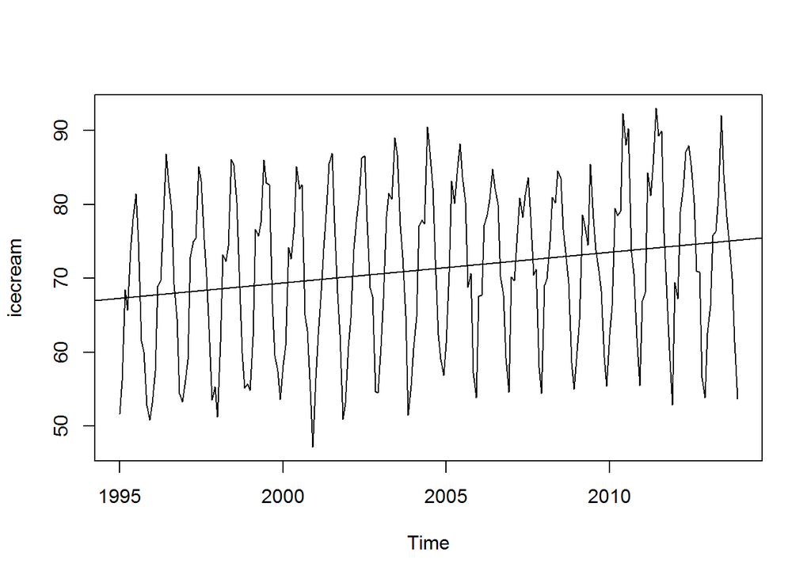

```r
plot(icecream)
abline(reg=lm(icecream ~ time(icecream)))
```

The seasonal components are readily apparent. However, still unsure about heteroscedasticity. As well, the trend component may be mild enough or skewed to still consider stationary; we should apply a test to verify.

As a gut check on heteroscedasticity, now look side by side with a log transform.

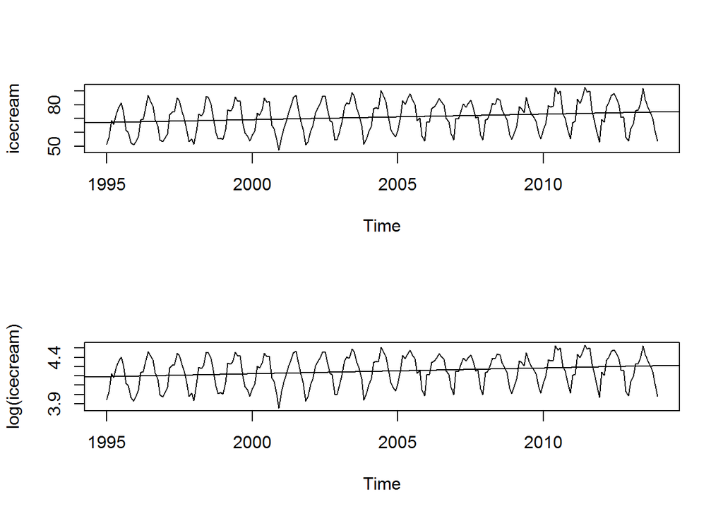

```r
par(mfrow=c(2,1))
plot(icecream)
abline(reg=lm(icecream ~ time(icecream)))

plot(log(icecream))
abline(reg=lm(log(icecream) ~ time(icecream)))
```

```r
par(mfrow=c(1,1))
```

The log transform appears not to make a huge difference.

Now lets inspect standard deviation by year. If heteroskedasticity exists, then we should see a trend in the standard deviation.

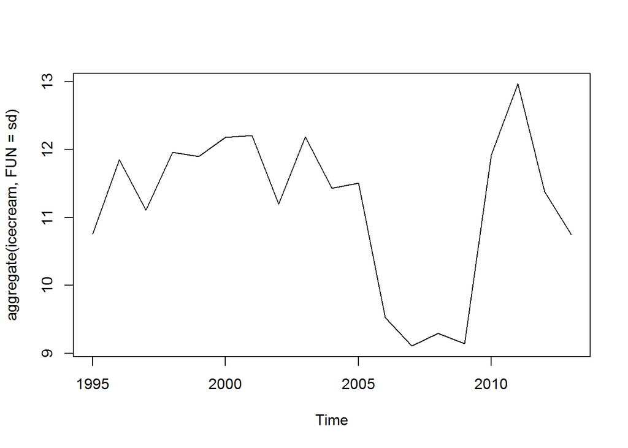

```r
plot(aggregate(icecream, FUN = sd))
```

Appears an anamoly exists in 2006-2009, but no overall trend exists.

Now finally to test if the series is stationary, lets use the Augmented Dickey-Fuller test, which has the null hypothesis of the series not being stationary.

```r
adf.test(icecream, alternative = 'stationary')
```

```
##
##  Augmented Dickey-Fuller Test
##
## data:  icecream
## Dickey-Fuller = -10.376, Lag order = 6, p-value = 0.01
## alternative hypothesis: stationary
```

We reject the null hypothesis and accept the alternative hypothesis that the series is stationary.

Now lets inspect the ACF and PACF plots.

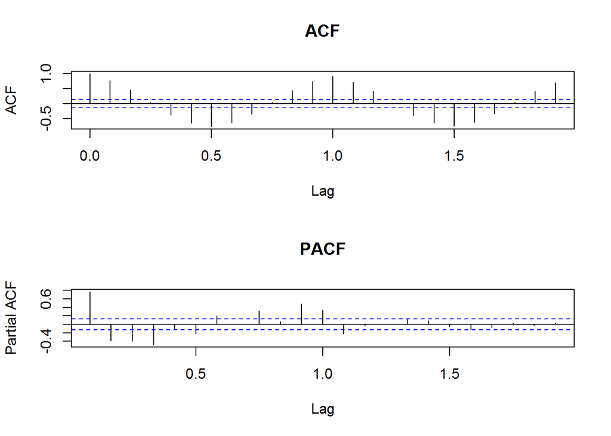

```r
acf_plots <- function(ts) {
  par(mfrow=c(2,1))
  acf(ts, main = "ACF")
  pacf(ts, main = "PACF")
  par(mfrow=c(1,1))
}

acf_plots(icecream)
```

It is clear from the ACF plot that there is large seasonal component at play.

### Run ARMA on remainder of the decomposed series

First lets decompose the series into seasonal, trend, and remainder components.

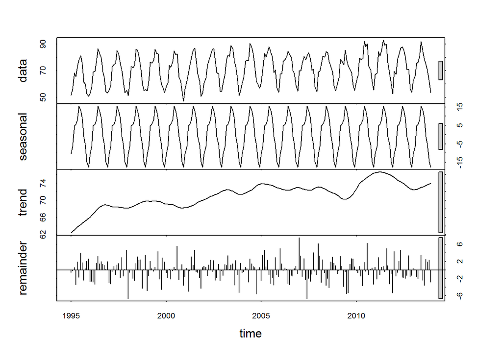

```r
icecream_decomp <- stl(icecream, s.window = 'periodic')

plot(icecream_decomp)
```

Now we begin fitting ARMA models to the remainder of the series.

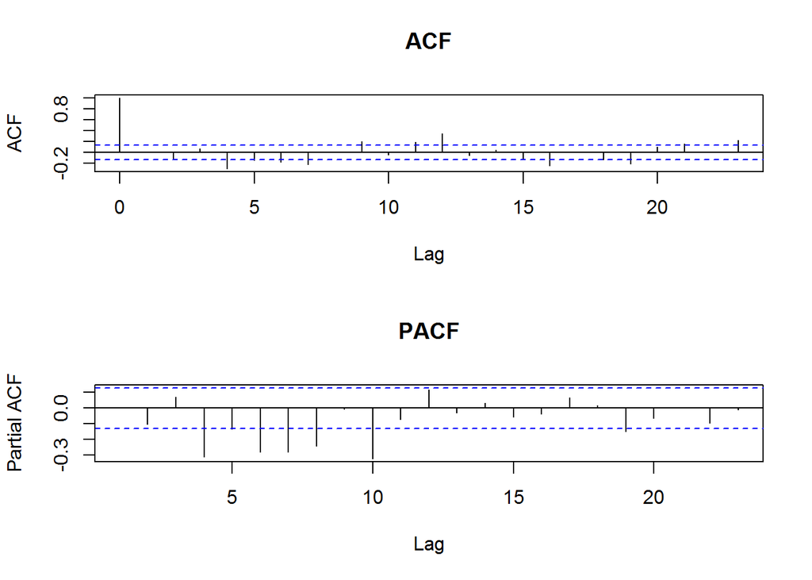

```r
# AR(1)
fit_arma10 <- arima(icecream_decomp$time.series[,'remainder'], order = c(1,0,0))
acf_plots(fit_arma10$residuals[-1])
```

```r
# not a good fit
```

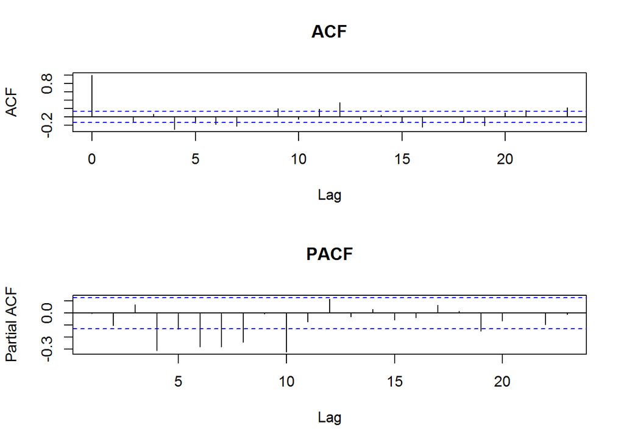

```r
# MA(1)
fit_arma01 <- arima(icecream_decomp$time.series[,'remainder'], order = c(0,0,1))
acf_plots(fit_arma01$residuals[-1])
```

```r
# not a good fit
```

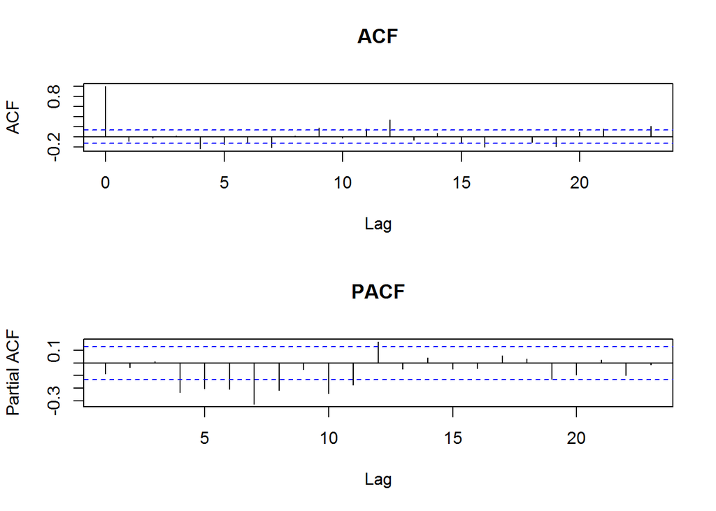

```r
# ARMA(1,1)
fit_arma11 <- arima(icecream_decomp$time.series[,'remainder'], order = c(1,0,1))
acf_plots(fit_arma11$residuals[-1])
```

```r
# also not a good fit
```

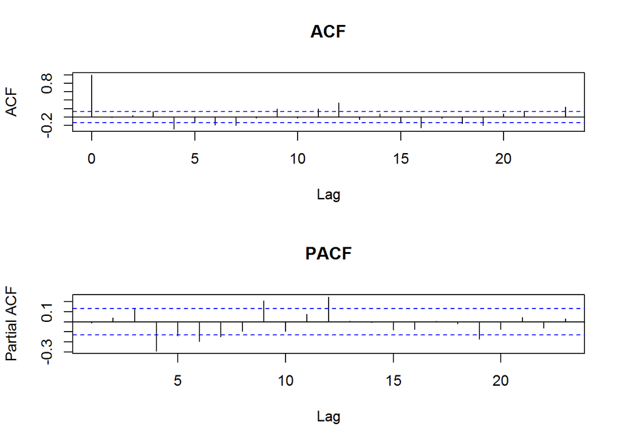

```r
# ARMA(1,2)
fit_arma12 <- arima(icecream_decomp$time.series[,'remainder'], order = c(1,0,2))
acf_plots(fit_arma12$residuals[-1])
```

```r
# becoming tedious...
```

Instead of continuing to brute force it, lets use `auto.arima`.

```r
# bring in the big guns
fit_arma <- auto.arima(icecream_decomp$time.series[,'remainder'],
                         max.p = 5, max.d = 0, max.q = 5,
                         max.order = 5, seasonal = FALSE, stepwise = FALSE)
summary(fit_arma)
```

```
## Series: icecream_decomp$time.series[, "remainder"]
## ARIMA(0,0,4) with zero mean
##
## Coefficients:
##           ma1      ma2      ma3      ma4
##       -0.1543  -0.3795  -0.0695  -0.3496
## s.e.   0.0657   0.0577   0.0667   0.0536
##
## sigma^2 estimated as 4.758:  log likelihood=-501.34
## AIC=1012.67   AICc=1012.94   BIC=1029.82
##
## Training set error measures:
##                     ME     RMSE      MAE      MPE     MAPE      MASE
## Training set 0.1874705 2.181275 1.736032 475.0779 535.8233 0.7630889
##                     ACF1
## Training set 0.003157389
```

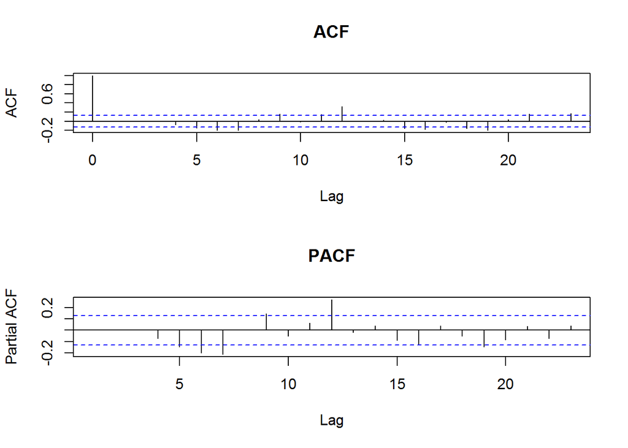

```r
acf_plots(fit_arma$residuals[-1])
```

Diagnostic plots look good. ARMA(0,4) has it!

### Train ARIMA & forecast ice cream production

Now we use `auto.arima` to train

```r
fit_arima <- auto.arima(icecream, max.p=3, max.q=3,
                         max.P=2, max.Q=2, max.order=5,
                         max.d=2, max.D=1, start.p=0,
                         start.q=0, start.P=0, start.Q=0)

summary(fit_arima)
```

```
## Series: icecream
## ARIMA(3,0,1)(1,1,2)[12] with drift
##
## Coefficients:
##           ar1     ar2     ar3     ma1   sar1     sma1     sma2   drift
##       -0.3052  0.2177  0.3482  0.5655  0.026  -0.5470  -0.2335  0.0377
## s.e.   0.2020  0.0879  0.0648  0.2203  0.224   0.2184   0.1523  0.0101
##
## sigma^2 estimated as 7.426:  log likelihood=-528.05
## AIC=1074.11   AICc=1074.98   BIC=1104.49
##
## Training set error measures:
##                      ME     RMSE      MAE       MPE     MAPE      MASE
## Training set 0.09698592 2.652346 2.052637 0.0563378 2.892051 0.7436829
##                      ACF1
## Training set -0.005397972
```

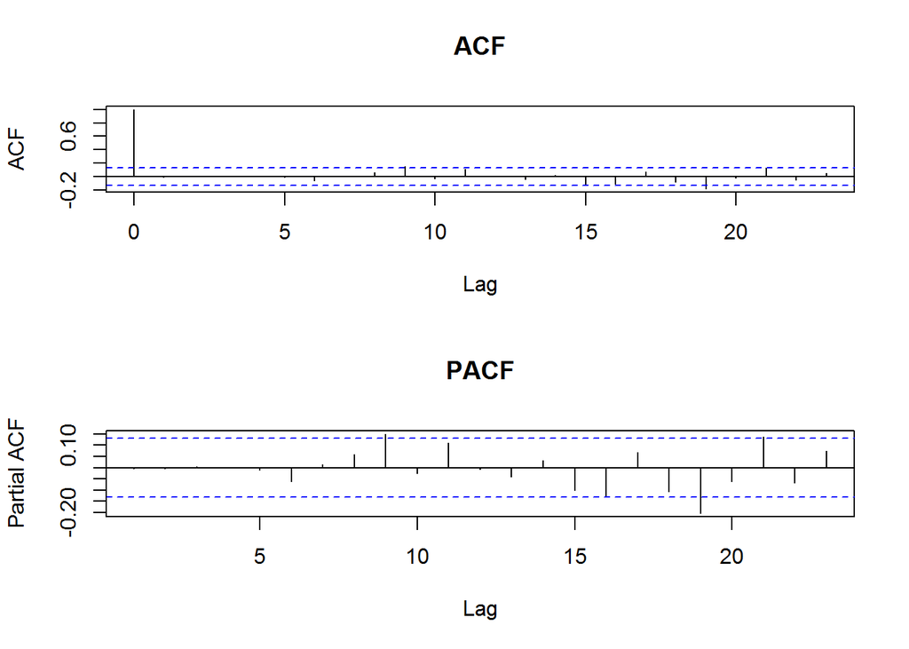

```r
acf_plots(fit_arima$residuals[-1])
```

Diagnostic plots are looking very good.

Now forecast out the next 12 months of production.

```r
icecream_forecast <- forecast(fit_arima, h=12)

summary(icecream_forecast)
```

```
##
## Forecast method: ARIMA(3,0,1)(1,1,2)[12] with drift
##
## Model Information:
## Series: icecream
## ARIMA(3,0,1)(1,1,2)[12] with drift
##
## Coefficients:
##           ar1     ar2     ar3     ma1   sar1     sma1     sma2   drift
##       -0.3052  0.2177  0.3482  0.5655  0.026  -0.5470  -0.2335  0.0377
## s.e.   0.2020  0.0879  0.0648  0.2203  0.224   0.2184   0.1523  0.0101
##
## sigma^2 estimated as 7.426:  log likelihood=-528.05
## AIC=1074.11   AICc=1074.98   BIC=1104.49
##
## Error measures:
##                      ME     RMSE      MAE       MPE     MAPE      MASE
## Training set 0.09698592 2.652346 2.052637 0.0563378 2.892051 0.7436829
##                      ACF1
## Training set -0.005397972
##
## Forecasts:
##          Point Forecast    Lo 80    Hi 80    Lo 95    Hi 95
## Jan 2014       63.62479 60.13219 67.11739 58.28331 68.96626
## Feb 2014       68.89726 65.28829 72.50624 63.37781 74.41671
## Mar 2014       77.71948 74.07833 81.36063 72.15082 83.28814
## Apr 2014       79.58273 75.72762 83.43784 73.68684 85.47862
## May 2014       82.28689 78.43162 86.14217 76.39076 88.18303
## Jun 2014       91.41106 87.53153 95.29059 85.47783 97.34429
## Jul 2014       86.60755 82.71513 90.49996 80.65461 92.56048
## Aug 2014       82.04068 78.14825 85.93310 76.08773 87.99363
## Sep 2014       75.18685 71.28840 79.08530 69.22469 81.14902
## Oct 2014       70.61699 66.71828 74.51570 64.65443 76.57955
## Nov 2014       61.63109 57.73221 65.52997 55.66827 67.59391
## Dec 2014       55.87179 51.97221 59.77137 49.90789 61.83568
```

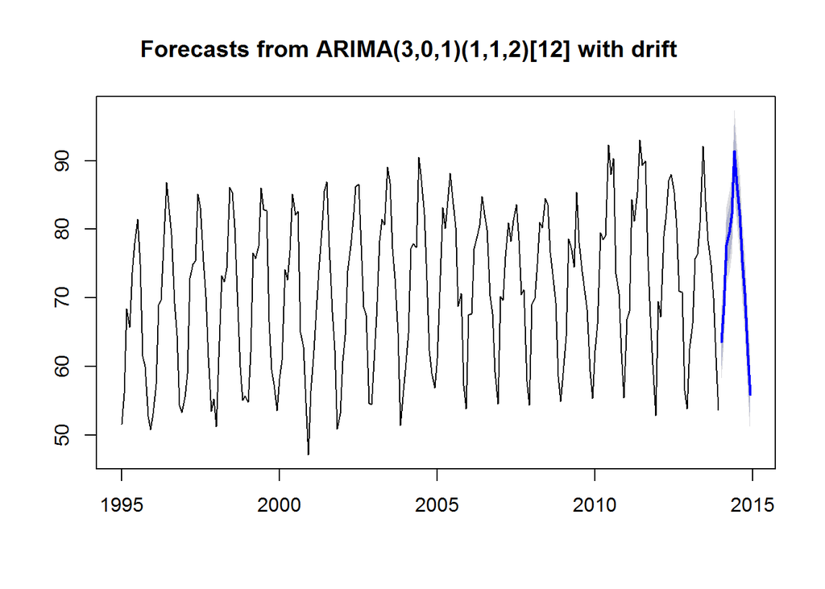

```r
plot(icecream_forecast)
```